# Intro to Machine Learning: Final Project

##### Author: Sean Kalsi

### Executive Summary:

This analysis will estimate the classification category for manner of barbell lift. The barbell lift activity data is collected using a Human Activity Recognition(har) device. Using a random forrest model we estimate an ~11% out of sample error for predicting the correct classification.

Background info & links to datasets used: http://web.archive.org/web/20161224072740/http:/groupware.les.inf.puc-rio.br/har

### Data Partitioning:

To start with I split the training set into 3 parts: 1/4 for testing, 9/16 for training, 3/16 for validation.

```r
training1 <- read.csv("pml-training.csv")
testing1 <- read.csv("pml-testing.csv")

inTrain = createDataPartition(training1$classe, p = 3/4)[[1]]

trainingFull = training1[ inTrain,]
testing = training1[-inTrain,]

withinTrain = createDataPartition(trainingFull$classe, p = 3/4)[[1]]
training = trainingFull[ withinTrain,]
validation = trainingFull[-withinTrain,]
```

### Data Exploration:

To start with I examined the dataset to see how many of the 159 predictors were measured for all rows in the training set. It turns out 60 out of 159 contain no missing data.

```r
len <- length(training)
lenVals <- length(training$classe)

nval <- 0
for(i in 1:len){
  if(class(training[,i]) == "factor"){
    nasum <- sum(training[,i] != "")
  }
  else nasum <- sum(!is.na(training[,i]))
  if(nasum == lenVals){
    if(nval<1){
      ind <- i
      vals <- nasum
      nval <- nval+1
    }
    else{
      ind <- c(ind,i)
      vals <- c(vals,nasum)
    }
  }
}
```

Then I made plots of these 60 varriables and examined which variables showed the most distinct clustering. It appeared that after taking into account the user name some clear patterns emerged. The following variables appeared to have the strongest clustering: “roll_belt”, “pitch_belt”, “yaw_belt”, “total_accel_belt”, & “gyros_belt_x”. As an example the plot below shows “pitch+belt” vs classe.

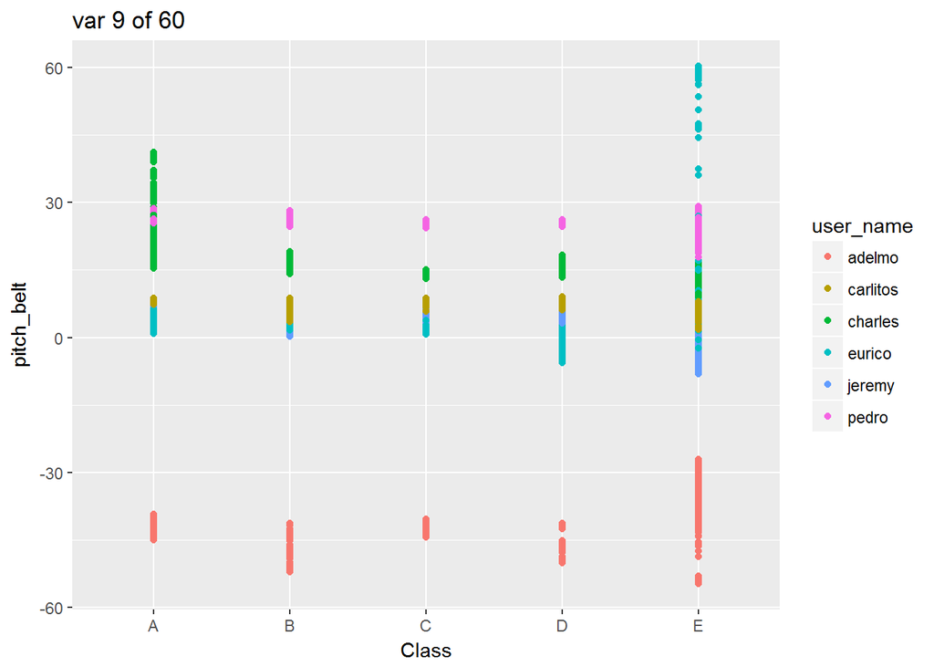

### Model Exploration:

```r
outVar <- "classe"
subset <- names(training)[ind]
subset2 <- subset[c(8,9,10,11,12)]
predVars <- paste(subset2,collapse = " + ")
formula <- as.formula(paste(outVar,predVars,sep = " ~ "))

actTrain <- training$classe
actValid <- validation$classe

modelNames <- c("rf","rpart","nb","knn")

acTrain <- vector(length = length(modelNames),mode="numeric")
acValidation <- vector(length = length(modelNames),mode="numeric")

for(i in 1:length(modelNames)){

  mod <- train(formula, method=modelNames[i], data=training)

  pred <- predict(mod,training)
  acTrain[i] <- sum(pred==actTrain)/length(actTrain)
  pred <- predict(mod,validation)
  acValidation[i] <- sum(pred==actValid)/length(actValid)
}
data.frame(modelNames,acTrain,acValidation)
```

```
##   modelNames   acTrain acValidation
## 1         rf 0.9986413    0.9105492
## 2      rpart 0.3940217    0.3931485
## 3         nb 0.4661232    0.4649266
## 4        knn 0.8971920    0.8523654
```

The Random Forrest model seemed to produce the best accuracy on the validation set. The next step was to cross validate this model. This cross validation tests had an average out of sample error of ~11% which was consistent with what this model predicted on the validation set.

```r
numCross  <- 4
acCrossTrain <- vector(length = numCross,mode="numeric")
acCrossTest <- vector(length = numCross,mode="numeric")

for(i in 1:numCross){
  inCross = createDataPartition(training$classe, p = 3/4)[[1]]
  trainCross = training[ inCross,]
  testCross = training[ -inCross,]
  actTrainCross <- trainCross$classe
  actTestCross <- testCross$classe
  mod <- train(formula, method="rf", data=trainCross)
  pred <- predict(mod,trainCross)
  acCrossTrain[i] <- sum(pred==actTrainCross)/length(actTrainCross)
  pred <- predict(mod,testCross)
  acCrossTest[i] <- sum(pred==actTestCross)/length(actTestCross)
}
data.frame(acCrossTrain,acCrossTest)
```

```
##   acCrossTrain acCrossTest
## 1    0.9987926   0.8792603
## 2    0.9980681   0.8894126
## 3    0.9978266   0.8854242
## 4    0.9973436   0.8785352
```

```r
1-mean(acCrossTest)
```

```
## [1] 0.1168419
```

### Results

The Random Forrest Model produced a 11% out of sample error on the test set, which was consisitent with the cross validation, and validation sets.

```r
actTest <- testing$classe
mod <- train(formula, method="rf",data=training)
pred <- predict(mod,testing)
predVal <- predict(mod,validation)
1-sum(pred==actTest)/length(actTest)
```

```
## [1] 0.1072594
```

### Appendix

Here is the confusion Matrix for the Validation data

```r
confusionMatrix(predVal,actValid)
```

```
## Confusion Matrix and Statistics
##
##           Reference
## Prediction   A   B   C   D   E
##          A 983  20  31  38  19
##          B  19 648  39   7   9
##          C  25  39 534  14   0
##          D  13   3  28 532   3
##          E   6   2   9  12 645
##
## Overall Statistics
##
##                Accuracy : 0.9086
##                  95% CI : (0.8989, 0.9178)
##     No Information Rate : 0.2844
##     P-Value [Acc > NIR] : < 2.2e-16
##
##                   Kappa : 0.8842
##  Mcnemar's Test P-Value : 2.359e-06
##
## Statistics by Class:
##
##                      Class: A Class: B Class: C Class: D Class: E
## Sensitivity            0.9398   0.9101   0.8331   0.8823   0.9541
## Specificity            0.9590   0.9751   0.9743   0.9847   0.9903
## Pos Pred Value         0.9010   0.8975   0.8725   0.9188   0.9570
## Neg Pred Value         0.9756   0.9783   0.9651   0.9771   0.9897
## Prevalence             0.2844   0.1936   0.1743   0.1639   0.1838
## Detection Rate         0.2673   0.1762   0.1452   0.1446   0.1754
## Detection Prevalence   0.2966   0.1963   0.1664   0.1574   0.1833
## Balanced Accuracy      0.9494   0.9426   0.9037   0.9335   0.9722
```

Here is the confusion Matrix for the Test data

```r
confusionMatrix(pred,actTest)
```

```
## Confusion Matrix and Statistics
##
##           Reference
## Prediction    A    B    C    D    E
##          A 1285   37   50   51   14
##          B   33  821   48   13    6
##          C   47   78  704   31    9
##          D   21    8   46  701    5
##          E    9    5    7    8  867
##
## Overall Statistics
##
##                Accuracy : 0.8927
##                  95% CI : (0.8837, 0.9013)
##     No Information Rate : 0.2845
##     P-Value [Acc > NIR] : < 2.2e-16
##
##                   Kappa : 0.8642
##  Mcnemar's Test P-Value : 0.003484
##
## Statistics by Class:
##
##                      Class: A Class: B Class: C Class: D Class: E
## Sensitivity            0.9211   0.8651   0.8234   0.8719   0.9623
## Specificity            0.9567   0.9747   0.9592   0.9805   0.9928
## Pos Pred Value         0.8942   0.8914   0.8101   0.8976   0.9676
## Neg Pred Value         0.9683   0.9679   0.9626   0.9750   0.9915
## Prevalence             0.2845   0.1935   0.1743   0.1639   0.1837
## Detection Rate         0.2620   0.1674   0.1436   0.1429   0.1768
## Detection Prevalence   0.2930   0.1878   0.1772   0.1593   0.1827
## Balanced Accuracy      0.9389   0.9199   0.8913   0.9262   0.9775
```